# 存活分析_HW2(無母數估計存活函數)

B082040005 高念慈

2023-04-17

## HW 73-150行 & 200-217行

# K-M estimate

```r
data("drug6mp")
# head(drug6mp) # packages 'KMsurv'
```

```r
drug6mp_event = drug6mp[drug6mp$relapse==1,]
sort(drug6mp_event$t2)           # 6  6  6  7 10 13 16 22 23 (6-MP 的事件發生時間:t1...tD)
```

```
## [1]  6  6  6  7 10 13 16 22 23
```

```r
Surv(drug6mp$t2,drug6mp$relapse) # use Surv function to create survival object，Ti=min(xi,ci)
```

```
##  [1] 10   7  32+ 23  22   6  16  34+ 32+ 25+ 11+ 20+ 19+  6  17+ 35+  6  13   9+
## [20]  6+ 10+
```

```r
fit.km.6mp = survfit(Surv(t2,relapse)~1, data=drug6mp)
temp = summary(fit.km.6mp)
temp
```

```
## Call: survfit(formula = Surv(t2, relapse) ~ 1, data = drug6mp)
##
##  time n.risk n.event survival std.err lower 95% CI upper 95% CI
##     6     21       3    0.857  0.0764        0.720        1.000
##     7     17       1    0.807  0.0869        0.653        0.996
##    10     15       1    0.753  0.0963        0.586        0.968
##    13     12       1    0.690  0.1068        0.510        0.935
##    16     11       1    0.627  0.1141        0.439        0.896
##    22      7       1    0.538  0.1282        0.337        0.858
##    23      6       1    0.448  0.1346        0.249        0.807
```

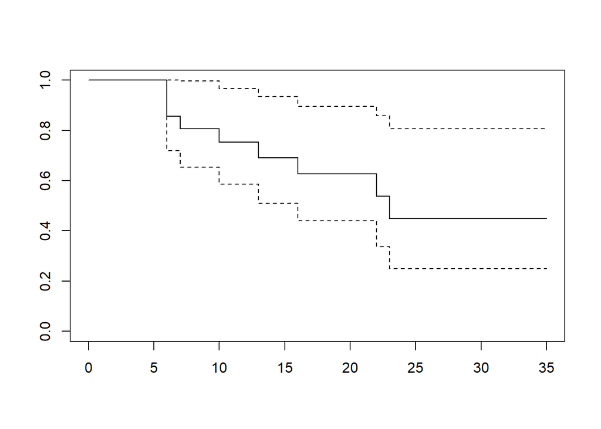

```r
plot(fit.km.6mp, conf.int=T)  # K-M estimate plot
```

```r
fit.km.6mp$n.risk             # Yi...YD
```

```
##  [1] 21 17 16 15 13 12 11 10  9  8  7  6  5  4  2  1
```

- [Compute a Survival Curve for Censored Data(截尾數據)](http://stat.ethz.ch/R-manual/R-patched/library/survival/html/survfit.formula.html)
- [在 R 中為生存選擇 conf.type](https://stats.stackexchange.com/questions/361354/choosing-conf-type-for-survfit-in-r)

```r
fit.km.6mp = survfit(Surv(t2,relapse)~1, data=drug6mp, conf.type="log-log")
summary(fit.km.6mp)  # conf.type=c("log","log-log","plain","none")
```

```
## Call: survfit(formula = Surv(t2, relapse) ~ 1, data = drug6mp, conf.type = "log-log")
##
##  time n.risk n.event survival std.err lower 95% CI upper 95% CI
##     6     21       3    0.857  0.0764        0.620        0.952
##     7     17       1    0.807  0.0869        0.563        0.923
##    10     15       1    0.753  0.0963        0.503        0.889
##    13     12       1    0.690  0.1068        0.432        0.849
##    16     11       1    0.627  0.1141        0.368        0.805
##    22      7       1    0.538  0.1282        0.268        0.747
##    23      6       1    0.448  0.1346        0.188        0.680
```

type 方法  
+ “kaplan-meier”，相當於 stype=1、ctype=1 + “fleming-harrington”，相當於 stype=2、ctype=1 和 “fh2”

```r
fit.km.6mp = survfit(Surv(t2,relapse)~1, data=drug6mp, type="fh2")
summary(fit.km.6mp)
```

```
## Call: survfit(formula = Surv(t2, relapse) ~ 1, data = drug6mp, type = "fh2")
##
##  time n.risk n.event survival std.err lower 95% CI upper 95% CI
##     6     21       3    0.860  0.0747        0.726        1.000
##     7     17       1    0.811  0.0851        0.661        0.996
##    10     15       1    0.759  0.0943        0.595        0.968
##    13     12       1    0.698  0.1045        0.521        0.936
##    16     11       1    0.638  0.1116        0.452        0.899
##    22      7       1    0.553  0.1249        0.355        0.861
##    23      6       1    0.468  0.1314        0.270        0.811
```

- 累積風險函數
- $S(t)=e^{-H(t)}$

```r
list(temp$time,-log(temp$surv))
```

```
## [[1]]
## [1]  6  7 10 13 16 22 23
##
## [[2]]
## [1] 0.1541507 0.2147753 0.2837682 0.3707796 0.4660897 0.6202404 0.8025620
```

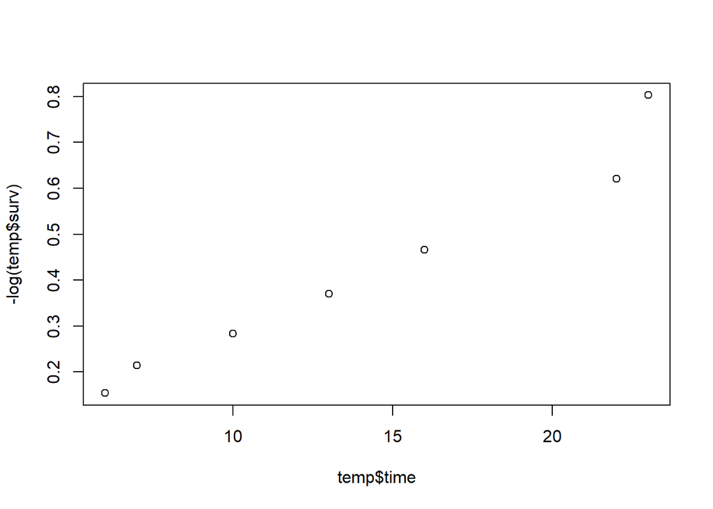

```r
plot(temp$time,-log(temp$surv))
```

## Homework: (6mp, t1(placebo), relapse)

## (1)

Calculate K-M estimator for S(t) and variance estimate and 99% confidence interval for S(t)

```r
fit.km.6mp = survfit(Surv(t1,relapse)~1, data=drug6mp, ctype=1, conf.int = .99, conf.type="log-log")
summary(fit.km.6mp)
```

```
## Call: survfit(formula = Surv(t1, relapse) ~ 1, data = drug6mp, ctype = 1,
##     conf.int = 0.99, conf.type = "log-log")
##
##  time n.risk n.event survival std.err lower 99% CI upper 99% CI
##     1     21       1    0.952  0.0465       0.5266        0.996
##     2     19       1    0.902  0.0657       0.5287        0.984
##     5     14       1    0.838  0.0871       0.4479        0.962
##     8     12       1    0.768  0.1041       0.3713        0.932
##    11      8       1    0.672  0.1279       0.2555        0.891
##    12      6       1    0.560  0.1477       0.1539        0.836
##    15      4       1    0.420  0.1642       0.0627        0.762
##    17      3       1    0.280  0.1583       0.0184        0.667
##    22      2       1    0.140  0.1267       0.0016        0.549
```

- [Be careful with standard errors in `survival::survfit`](https://dominicmagirr.github.io/post/2022-01-18-be-careful-with-standard-errors-in-survival-survfit/)

```r
round(cbind("累積危害的標準誤差" = fit.km.6mp$std.err,
      '個別標準誤差' = summary((fit.km.6mp))$std.err,
      'variance estimate' = (summary((fit.km.6mp))$std.err)^2),4)
```

```
##       累積危害的標準誤差 個別標準誤差 variance estimate
##  [1,]             0.0488       0.0465            0.0022
##  [2,]             0.0728       0.0657            0.0043
##  [3,]             0.0728       0.0871            0.0076
##  [4,]             0.0728       0.1041            0.0108
##  [5,]             0.1039       0.1279            0.0164
##  [6,]             0.1356       0.1477            0.0218
##  [7,]             0.1903       0.1642            0.0270
##  [8,]             0.2638       0.1583            0.0251
##  [9,]             0.3910       0.1267            0.0161
## [10,]             0.5653       0.0465            0.0022
## [11,]             0.9053       0.0657            0.0043
## [12,]             0.9053       0.0871            0.0076
```

- K-M estimator
- variance estimate
- 99% confidence interval

```r
round(cbind('K-M estimator'=fit.km.6mp$surv,
            'variance estimate'=(summary((fit.km.6mp))$std.err)^2,
            '99% confidence lower'=fit.km.6mp$lower,
            '99% confidence upper'=fit.km.6mp$upper),4)
```

```
##       K-M estimator variance estimate 99% confidence lower 99% confidence upper
##  [1,]        0.9524            0.0022               0.5266               0.9963
##  [2,]        0.9023            0.0043               0.5287               0.9835
##  [3,]        0.9023            0.0076               0.5287               0.9835
##  [4,]        0.9023            0.0108               0.5287               0.9835
##  [5,]        0.8378            0.0164               0.4479               0.9618
##  [6,]        0.7680            0.0218               0.3713               0.9321
##  [7,]        0.6720            0.0270               0.2555               0.8907
##  [8,]        0.5600            0.0251               0.1539               0.8356
##  [9,]        0.4200            0.0161               0.0627               0.7621
## [10,]        0.2800            0.0022               0.0184               0.6666
## [11,]        0.1400            0.0043               0.0016               0.5485
## [12,]        0.1400            0.0076               0.0016               0.5485
```

## (2)

Plot K-M estimators vs. time

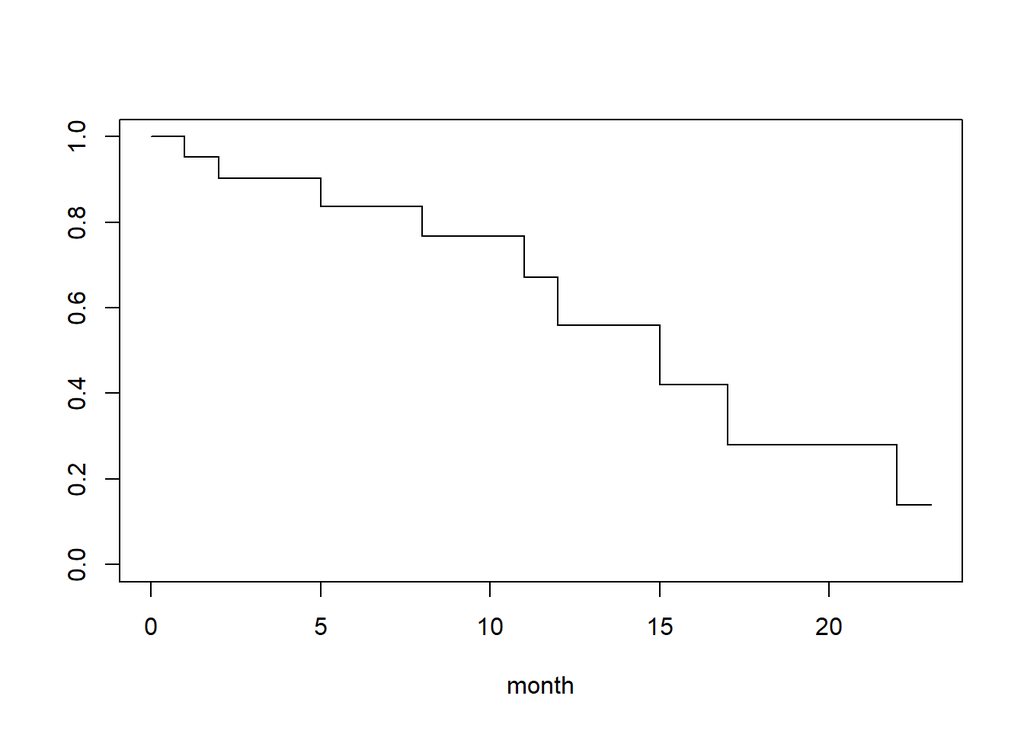

```r
plot(fit.km.6mp, conf.int=F, xlab='month')  # K-M estimate plot
```

## (3)

Calculate the cumulative hazard function H(t) using the K-M estimator

- 累積風險函數
- $S(t)=e^{-H(t)}$
- $-log(S(t)=H(t))$

```r
cbind("time" = fit.km.6mp$time,
      "H(t)" = -log(fit.km.6mp$surv))
```

```
##       time       H(t)
##  [1,]    1 0.04879016
##  [2,]    2 0.10285739
##  [3,]    3 0.10285739
##  [4,]    4 0.10285739
##  [5,]    5 0.17696536
##  [6,]    8 0.26397673
##  [7,]   11 0.39750813
##  [8,]   12 0.57982968
##  [9,]   15 0.86751176
## [10,]   17 1.27297686
## [11,]   22 1.96612405
## [12,]   23 1.96612405
```

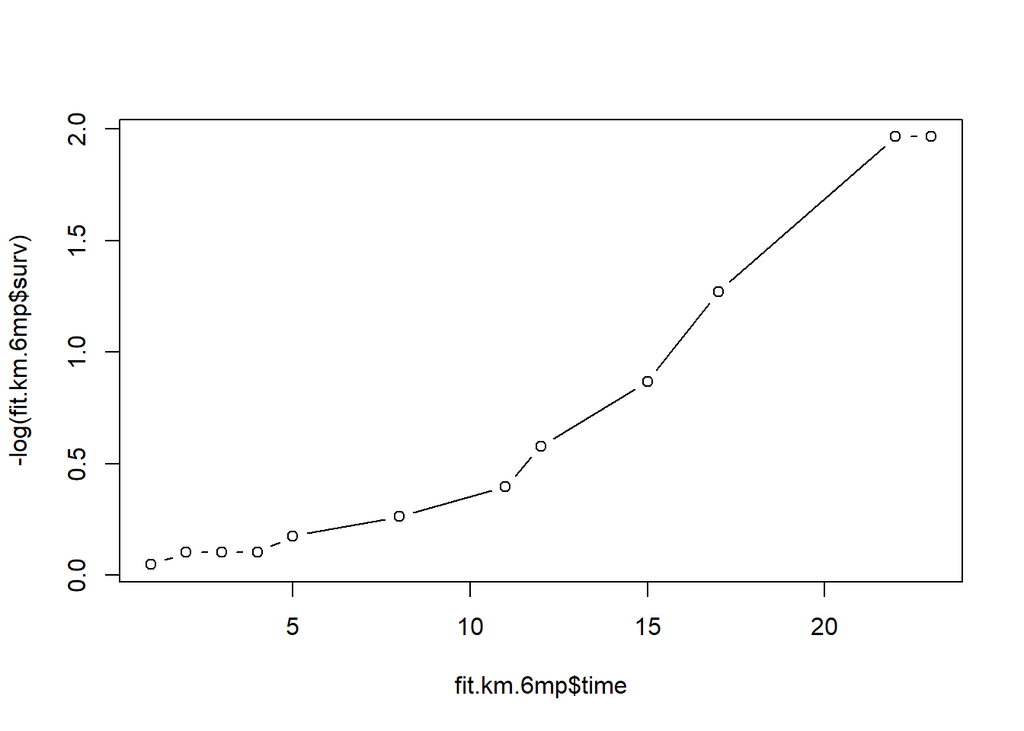

```r
plot(fit.km.6mp$time, -log(fit.km.6mp$surv), type="b")
```

## (4)

Calculate the Nelson-Aalen estimator for H(t) and S(t)

```r
H_t = rep(0,length(fit.km.6mp$time))
s_t = rep(0,length(fit.km.6mp$time))

for (i in length(fit.km.6mp$time):1){
  H_t[i] = sum((fit.km.6mp$n.event/fit.km.6mp$n.risk)[1:i])
}

s_t = exp(-H_t)

cbind('NA_H(t)' = H_t,
      "NA_S(t)" = s_t)
```

```
##          NA_H(t)   NA_S(t)
##  [1,] 0.04761905 0.9534970
##  [2,] 0.10025063 0.9046107
##  [3,] 0.10025063 0.9046107
##  [4,] 0.10025063 0.9046107
##  [5,] 0.17167920 0.8422493
##  [6,] 0.25501253 0.7749068
##  [7,] 0.38001253 0.6838528
##  [8,] 0.54667920 0.5788689
##  [9,] 0.79667920 0.4508236
## [10,] 1.13001253 0.3230292
## [11,] 1.63001253 0.1959271
## [12,] 1.63001253 0.1959271
```

## (5)

Plot H(t) vs. t to check whether the distribution of the time-to-event random variable is exponential

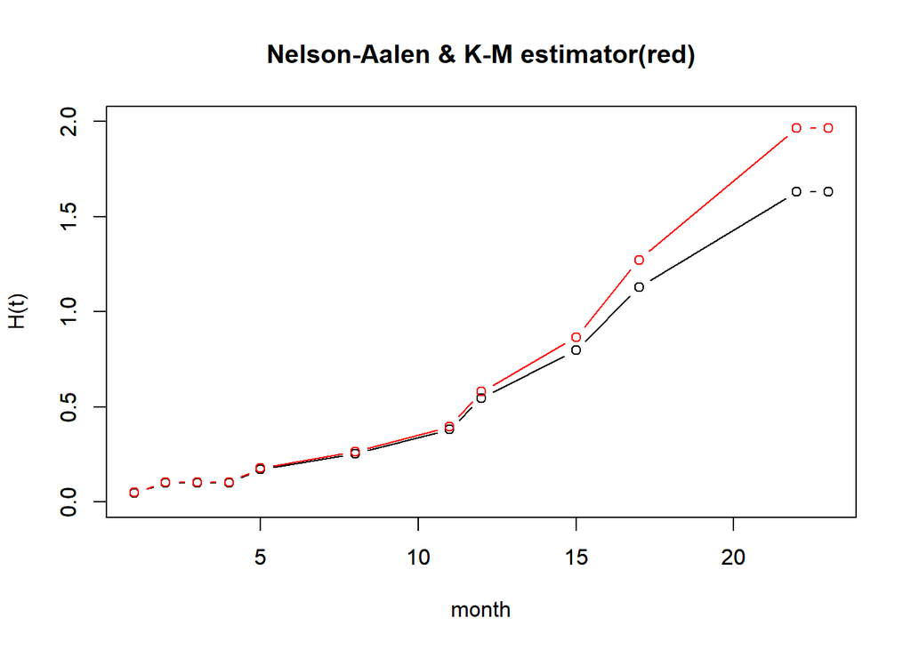

```r
plot(fit.km.6mp$time, H_t, type="b", xlab="month", ylim=c(0,2), main="Nelson-Aalen & K-M estimator(red)", ylab='H(t)')
par(new=TRUE)
plot(fit.km.6mp$time, -log(fit.km.6mp$surv), type="b", col="red", xlab='', ylab='' , ylim=c(0,2))
```

# Left-truncated and right-censored data

```r
data(channing)

channing_new = channing[channing[,"ageentry"]<channing[,"age"],] # 4筆進院=出院
# only keep the subjects whose entry time (Lj) are less than the corresponding study time (Tj)

channing_new_male = channing_new[channing_new[,"gender"]==1,]
# only keep the male subjects
```

- codes for calculating the risk sets for male subjects

```r
sort(channing_new_male$ageentry) # 排進院時間
```

```
##  [1]  751  759  782  806  817  820  821  823  830  835  835  836  836  837  843
## [16]  846  847  847  852  853  854  856  856  856  863  865  865  866  871  871
## [31]  875  876  878  878  879  883  885  886  890  891  893  894  898  900  906
## [46]  906  909  915  919  919  921  923  925  926  936  936  938  943  943  946
## [61]  953  955  955  956  959  960  962  962  964  966  967  967  969  969  971
## [76]  978  978  981  982  984  984  988 1007 1010 1010 1016 1020 1021 1027 1036
## [91] 1039 1041 1046 1051 1063 1073
```

```r
sort(channing_new_male[channing_new_male[,"death"]==1,"age"]) # 排死亡時間
```

```
##  [1]  777  781  869  872  876  893  894  898  907  909  911  927  932  945  948
## [16]  957  966  969  971  983  985  989  993  993  998 1009 1012 1012 1022 1025
## [31] 1029 1031 1033 1036 1043 1044 1053 1055 1059 1060 1080 1085 1094 1094 1128
## [46] 1139
```

```r
# cbind(channing_new$ageentry, channing_new$age)

fit = survfit(Surv(ageentry,age,death)~1, data=channing_new, subset=(gender==1))
summary(fit)
```

```
## Call: survfit(formula = Surv(ageentry, age, death) ~ 1, data = channing_new,
##     subset = (gender == 1))
##
##  time n.risk n.event survival std.err lower 95% CI upper 95% CI
##   777      2       1      0.5   0.354        0.125            1
##   781      1       1      0.0     NaN           NA           NA
##   869     24       1      0.0     NaN           NA           NA
##   872     25       1      0.0     NaN           NA           NA
##   876     25       1      0.0     NaN           NA           NA
##   893     33       1      0.0     NaN           NA           NA
##   894     33       1      0.0     NaN           NA           NA
##   898     32       1      0.0     NaN           NA           NA
##   907     34       1      0.0     NaN           NA           NA
##   909     33       1      0.0     NaN           NA           NA
##   911     33       1      0.0     NaN           NA           NA
```

[output cut: 32 more lines]

- Now we only consider those deaths that occur after age 68 years old, that is P(X>t|X>68 years old)

```r
fit_age = survfit(Surv(ageentry,age,death)~1, data=channing_new, subset=(gender==1 & age>=12*68))
summary(fit_age)
```

```
## Call: survfit(formula = Surv(ageentry, age, death) ~ 1, data = channing_new,
##     subset = (gender == 1 & age >= 12 * 68))
##
##  time n.risk n.event survival std.err lower 95% CI upper 95% CI
##   869     24       1   0.9583  0.0408      0.88163        1.000
##   872     25       1   0.9200  0.0543      0.81957        1.000
##   876     25       1   0.8832  0.0634      0.76737        1.000
##   893     33       1   0.8564  0.0668      0.73495        0.998
##   894     33       1   0.8305  0.0697      0.70456        0.979
##   898     32       1   0.8045  0.0722      0.67482        0.959
##   907     34       1   0.7809  0.0738      0.64879        0.940
##   909     33       1   0.7572  0.0753      0.62314        0.920
##   911     33       1   0.7343  0.0764      0.59877        0.900
##   927     37       1   0.7144  0.0769      0.57855        0.882
##   932     36       1   0.6946  0.0773      0.55850        0.864
```

[output cut: 30 more lines]

- 以下不需要 run,但是可以看到為什麼不加 age>68 的限制時會發生的問題

```r
attach(channing_new_male) # 無需實際鍵入數據框的名稱，就可使數據框中的對象可訪問
aa <- cbind(ageentry, age, death)
## aa[order(-aa[,3], aa[,2]), ]
# aa[order(aa[,2]), ]
# aa[order(aa[,1]), ]
```

- 一次出現兩個Model

```r
fit_age = survfit(Surv(ageentry,age,death)~gender, data=channing_new, subset=(age>=12*68))
summary(fit_age)
```

```
## Call: survfit(formula = Surv(ageentry, age, death) ~ gender, data = channing_new,
##     subset = (age >= 12 * 68))
##
##                 gender=1
##  time n.risk n.event survival std.err lower 95% CI upper 95% CI
##   869     24       1   0.9583  0.0408      0.88163        1.000
##   872     25       1   0.9200  0.0543      0.81957        1.000
##   876     25       1   0.8832  0.0634      0.76737        1.000
##   893     33       1   0.8564  0.0668      0.73495        0.998
##   894     33       1   0.8305  0.0697      0.70456        0.979
##   898     32       1   0.8045  0.0722      0.67482        0.959
##   907     34       1   0.7809  0.0738      0.64879        0.940
##   909     33       1   0.7572  0.0753      0.62314        0.920
##   911     33       1   0.7343  0.0764      0.59877        0.900
##   927     37       1   0.7144  0.0769      0.57855        0.882
```

[output cut: 137 more lines]

## HW:女性

```r
fit_age = survfit(Surv(ageentry,age,death)~1,
                  data=channing_new,
                  subset=(gender==2 & age>=12*68),
                  conf.type="log-log")
summary(fit_age)
```

```
## Call: survfit(formula = Surv(ageentry, age, death) ~ 1, data = channing_new,
##     subset = (gender == 2 & age >= 12 * 68), conf.type = "log-log")
##
##  time n.risk n.event survival std.err lower 95% CI upper 95% CI
##   822     36       1   0.9722  0.0274      0.81873        0.996
##   830     46       1   0.9511  0.0340      0.81656        0.988
##   840     58       1   0.9347  0.0371      0.80736        0.979
##   845     66       1   0.9205  0.0392      0.79707        0.970
##   861     90       1   0.9103  0.0401      0.79031        0.963
##   868    100       1   0.9012  0.0407      0.78385        0.957
##   873    106       1   0.8927  0.0412      0.77744        0.950
##   883    116       1   0.8850  0.0415      0.77151        0.944
##   885    119       1   0.8776  0.0418      0.76555        0.938
##   895    137       1   0.8712  0.0420      0.76049        0.933
##   897    140       1   0.8649  0.0422      0.75546        0.928
```

[output cut: 92 more lines]

## survival curve

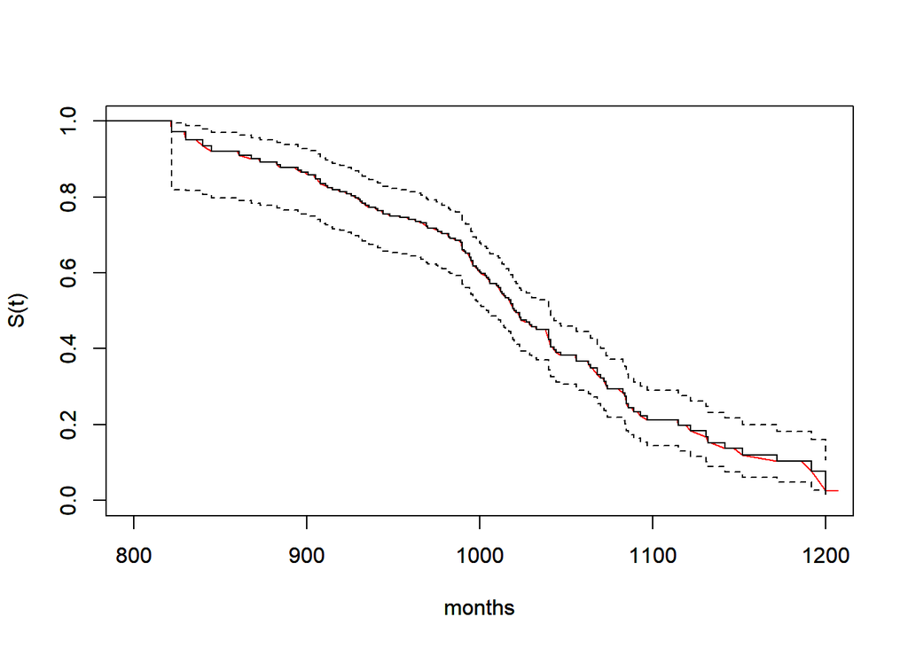

```r
plot(fit_age$time, fit_age$surv, type='l', xlab='months', ylab='S(t)', xlim=c(800,1200), ylim=c(0,1), col='red')
par(new=T)
plot(fit_age, xlab='months', ylab='S(t)', xlim=c(800,1200), ylim=c(0,1))
```

# Interval Censoring

```r
left = c(0,0,6,7,7,17,37, 45,46,46)
right = c(7,8,10,16,14,Inf,44,Inf,Inf,Inf)
cbind(left, right)
```

```
##       left right
##  [1,]    0     7
##  [2,]    0     8
##  [3,]    6    10
##  [4,]    7    16
##  [5,]    7    14
##  [6,]   17   Inf
##  [7,]   37    44
##  [8,]   45   Inf
##  [9,]   46   Inf
## [10,]   46   Inf
```

```r
fitll = ic_np(cbind(left, right)) # interval censore nonparametric # S(t) 的估計
summary(fitll)
```

```
##
## Model:  Non-parametric
## Dependency structure assumed: Independence
## No covariates used
##
## final llk =  -11.09035
## Iterations =  3
```

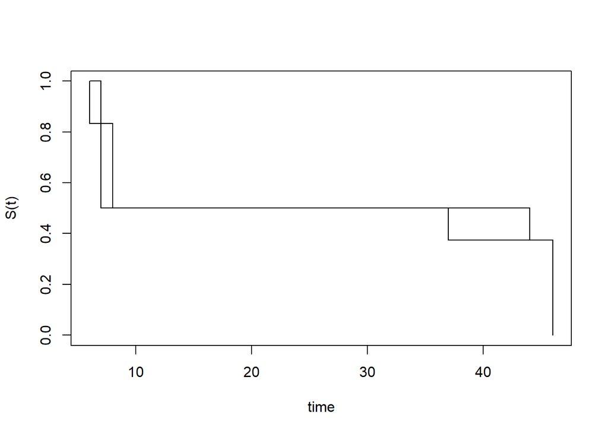

```r
plot(fitll)
```

```r
fitll$T_bull_Intervals # 看区間(正的机率)總和1
```

```
##      [,1] [,2] [,3] [,4]
## [1,]    6    7   37   46
## [2,]    7    8   44  Inf
```

```r
fitll$p_hat            # 每個區間的機率
```

```
## [1] 0.1666667 0.3333333 0.1250000 0.3750000
```

- for practice

```r
left = c(5,6,7,1,13,7,19)
right = c(9,14,8,15,15,20,Inf)
fit22 <- ic_np(cbind(left,right))
fit22$T_bull_Intervals
```

```
##      [,1] [,2] [,3]
## [1,]    7   13   19
## [2,]    8   14   20
```

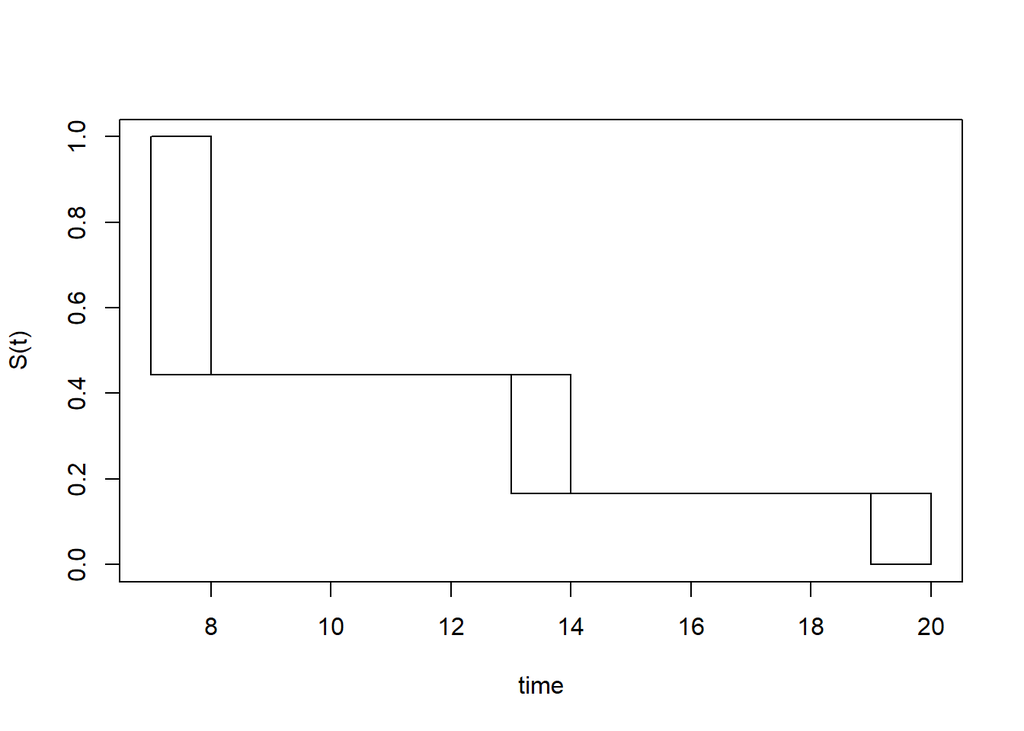

```r
plot(fit22)
```

# 未解釋

- Introduction for miceData r
- [miceData：來自 Hoel 和 Walburg 1972 的肺腫瘤間隔截尾數據](https://www.rdocumentation.org/packages/icenReg/versions/2.0.13/topics/miceData)

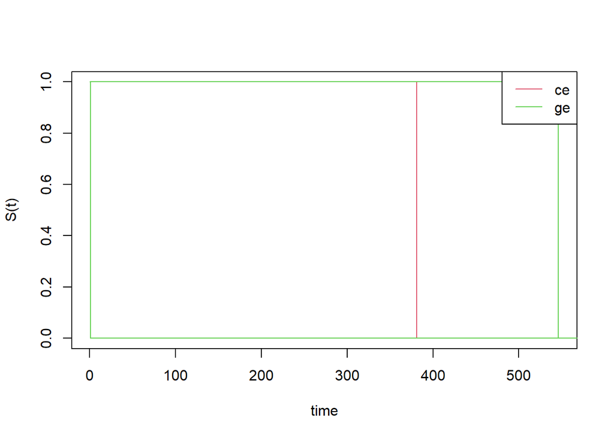

```r
data(miceData)
fit <- ic_np(cbind(1, u) ~ grp, data = miceData)  # Stratifies (分層) fits by group
plot(fit)
```

- HW: Please estimate the survival function
- for the time of developing lung cancer for mice in the conventional environment
- and also draw the plot for the estimator.
- 請估計小鼠在常規環境中患肺癌時間的生存函數，並為估計量畫圖

```r
# library('icenReg')
# data(miceData)
# head(miceData, 3)

# np_fit = ic_np(cbind(1, u) ~ grp, data = miceData)
# summary(np_fit)
# np_fit = ic_np(cbind(1, u) ~ 1, data = miceData)

# groupedFitl <- ic_np(cbind(l,u) ~ 0, data = miceData)
# plot(groupedFitl)
# summary(groupedFitl)
```

```r
if (!require("BiocManager", quietly = TRUE))
    install.packages("BiocManager")
# BiocManager::install("Icens")
# install.packages('interval')

library('BiocGenerics')
library('interval')
```

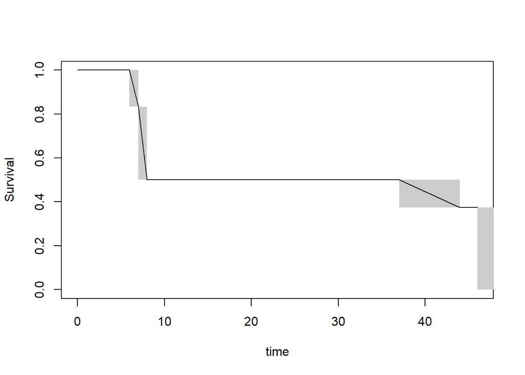

```r
id = c(1,2,3,4,5,6,7,8,9,10)
right = c(7,8,10,16,14,Inf,44,Inf,Inf,Inf)
left = c(0,0,6,7,7,17,37, 45,46,46)
k = cbind(id,left,right)
k = data.frame(k)

plot(icfit(left,right))
```

```r
fit <- icfit(Surv(left, right,type="interval2")~1, data=k)
```

- [JSTOR](https://www.jstor.org/stable/pdf/2530965.pdf?refreqid=excelsior:4cf1715a9c4f3bf3d2%202ae5c399898e33)
- paper: A Semiparametric Model for Regression Analysis of Interval-Censored Failure Time Data

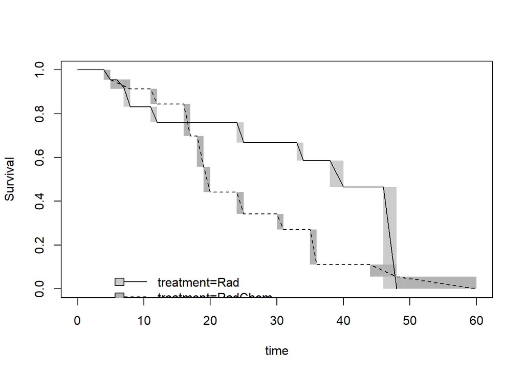

```r
# install.packages("KMsurv")
# install.packages("survival")
# library(KMsurv)
# library(survival)

data(bcos)

icout <- icfit(Surv(left, right, type="interval2")~treatment, data=bcos)
# icout <- icfit(Surv(left, right, type="interval2")~1, data-bcos)
plot(icout)
```

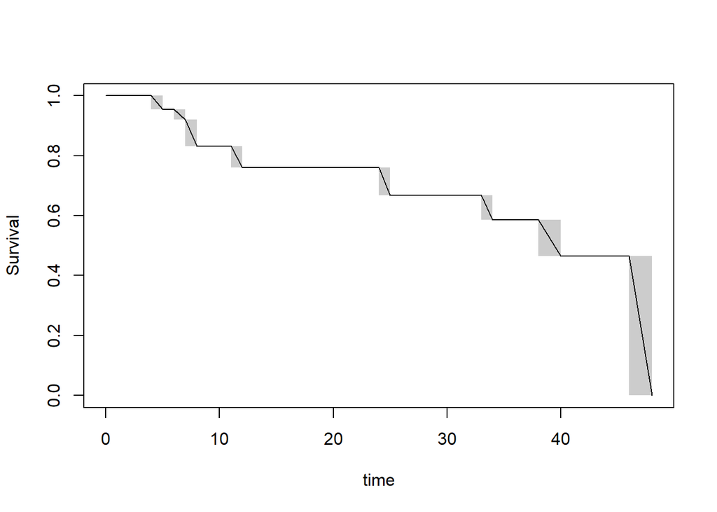

```r
## can pick out just one group
plot(icout[1])
```